# Course Project 1 Reproducible Research

Bliztacular

September 19, 2015

# Loading and preprocessing the data

Let’s load the data (i.e. read.csv()), then process/transform the data (if necessary) into a format suitable for our analysis.

```r
htr = c("integer", "character", "integer")
actdata <- read.csv("activity.csv", head=TRUE, colClasses=htr, na.strings="NA")
head(actdata)
```

```
##   steps       date interval
## 1    NA 2012-10-01        0
## 2    NA 2012-10-01        5
## 3    NA 2012-10-01       10
## 4    NA 2012-10-01       15
## 5    NA 2012-10-01       20
## 6    NA 2012-10-01       25
```

Now let’s change the date to be readable as a date, and save a copy of the dataset with the NA values removed.

```r
actdata$date <- as.Date(actdata$date)
actnna <- subset(actdata, !is.na(actdata$steps))
```

## What is mean total number of steps taken per day?

Ignoring the missing values, let’s calculate the total number of steps taken per day, make a histogram of the total number of steps taken each day, and then after we’ll calculate and report the mean and median of the total number of steps taken per day.

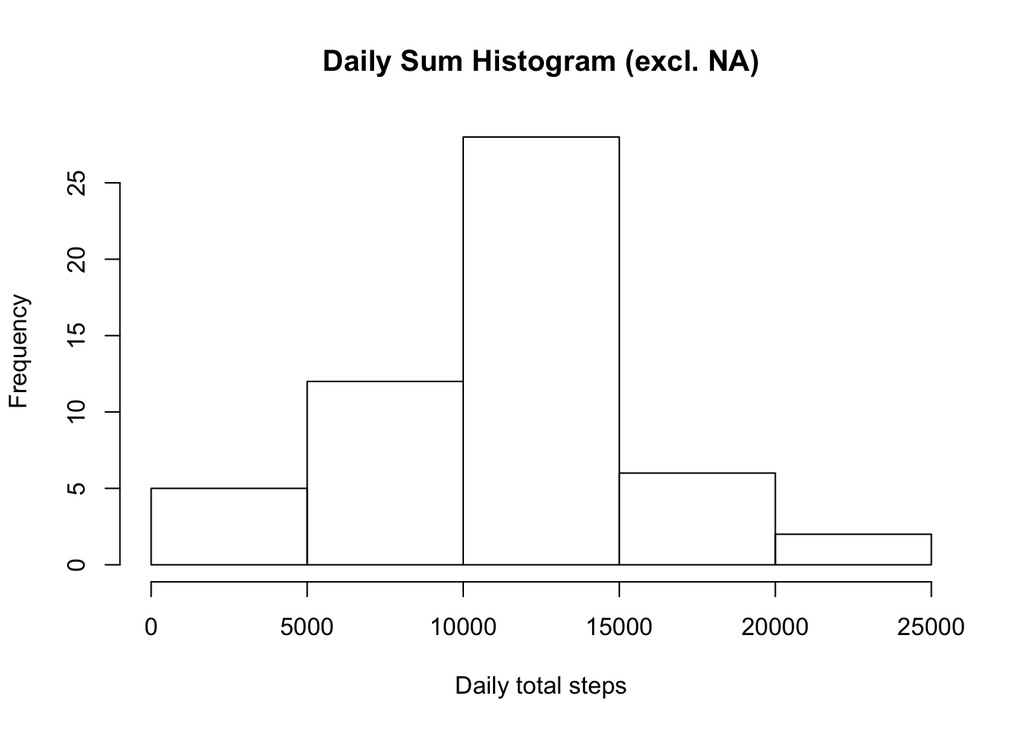

```r
dailysum <- tapply(actnna$steps, actnna$date, sum, na.rm=TRUE, simplify=T)
dailysum <- dailysum[!is.na(dailysum)]

hist(x=dailysum,
     xlab="Daily total steps",
     ylab="Frequency",
     main="Daily Sum Histogram (excl. NA)")
```

Now that we’ve looked at the distribution a bit, let’s calculate the mean and median.

```r
rmean <- mean(dailysum)
```

```r
rmedian <- median(dailysum)
```

## What is the average daily activity pattern?

Let’s make a time series plot (i.e. type = “l”) of the 5-minute interval (x-axis) and the average number of steps taken, averaged across all days (y-axis). Looking at the time series, which 5-minute interval, on average across all the days in the dataset, contains the maximum number of steps?

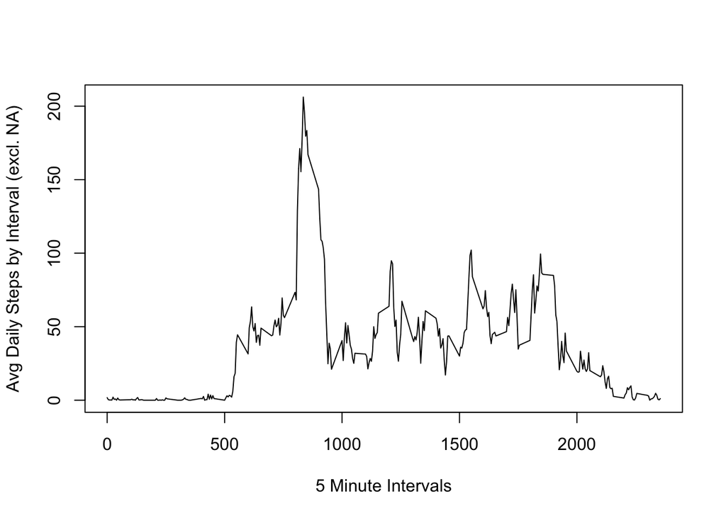

```r
int_avg <- tapply(actnna$steps, actnna$interval, mean, na.rm=TRUE, simplify=T)
df_ia <- data.frame(interval=as.integer(names(int_avg)), avg=int_avg)

with(df_ia,
     plot(interval,
          avg,
          type="l",
          xlab="5 Minute Intervals",
          ylab="Avg Daily Steps by Interval (excl. NA)"))
```

So, which interval contains the maximum number of steps?

```r
max_steps <- max(df_ia$avg)
df_ia[df_ia$avg == max_steps, ]
```

```
##     interval      avg
## 835      835 206.1698
```

## Imputing missing values

Let’s calculate and report the total number of missing values in the dataset (i.e. the total number of rows with NAs)

```r
sum(is.na(actdata$steps))
```

```
## [1] 2304
```

Now let’s replace the missing values with the mean/median for that day, or the mean for that 5-minute interval, etc., then create a new dataset that is equal to the original dataset but with the missing data filled in.

```r
df_impute <- actdata
nax <- is.na(df_impute$steps)
int_avg <- tapply(actnna$steps, actnna$interval, mean, na.rm=TRUE, simplify=T)
df_impute$steps[nax] <- int_avg[as.character(df_impute$interval[nax])]
```

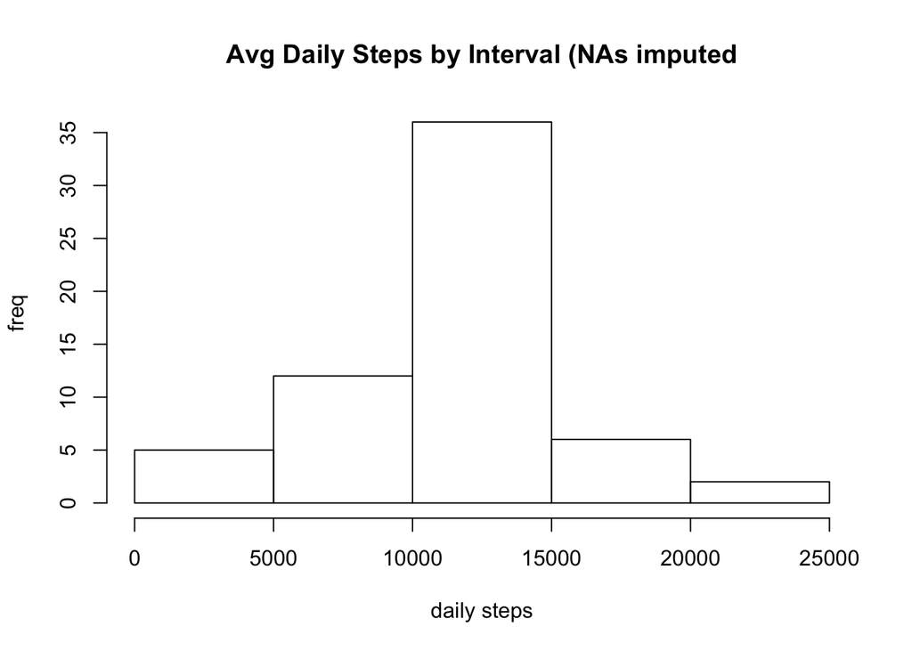

```r
new_dailysum <- tapply(df_impute$steps, df_impute$date, sum, na.rm=TRUE, simplify=T)

hist(x=new_dailysum,
     xlab="daily steps",
     ylab="freq",
     main="Avg Daily Steps by Interval (NAs imputed")
```

And now to look at the mean and median of the new dataset with imputed values to replace the NAs:

```r
zmean <- mean(new_dailysum)
```

```r
zmedian <- median(new_dailysum)
```

## Are there differences in activity patterns between weekdays and weekends?

We’ll use the weekdays() function here, and create a new factor variable in the dataset with two levels – “weekday” and “weekend” indicating whether a given date is a weekday or weekend day. Then we’ll show the first few rows of the data with a ‘wk’ column added.

```r
is_weekday <- function(d) {
    wd <- weekdays(d)
    ifelse (wd == "Saturday" | wd == "Sunday", "weekend", "weekday")
}

wx <- sapply(df_impute$date, is_weekday)
df_impute$wk <- as.factor(wx)
head(df_impute)
```

```
##       steps       date interval      wk
## 1 1.7169811 2012-10-01        0 weekday
## 2 0.3396226 2012-10-01        5 weekday
## 3 0.1320755 2012-10-01       10 weekday
## 4 0.1509434 2012-10-01       15 weekday
## 5 0.0754717 2012-10-01       20 weekday
## 6 2.0943396 2012-10-01       25 weekday
```

Finally, we’ll make a panel plot containing a time series plot (i.e. type = “l”) of the 5-minute interval (x-axis) and the average number of steps taken, averaged across all weekday days or weekend days (y-axis).

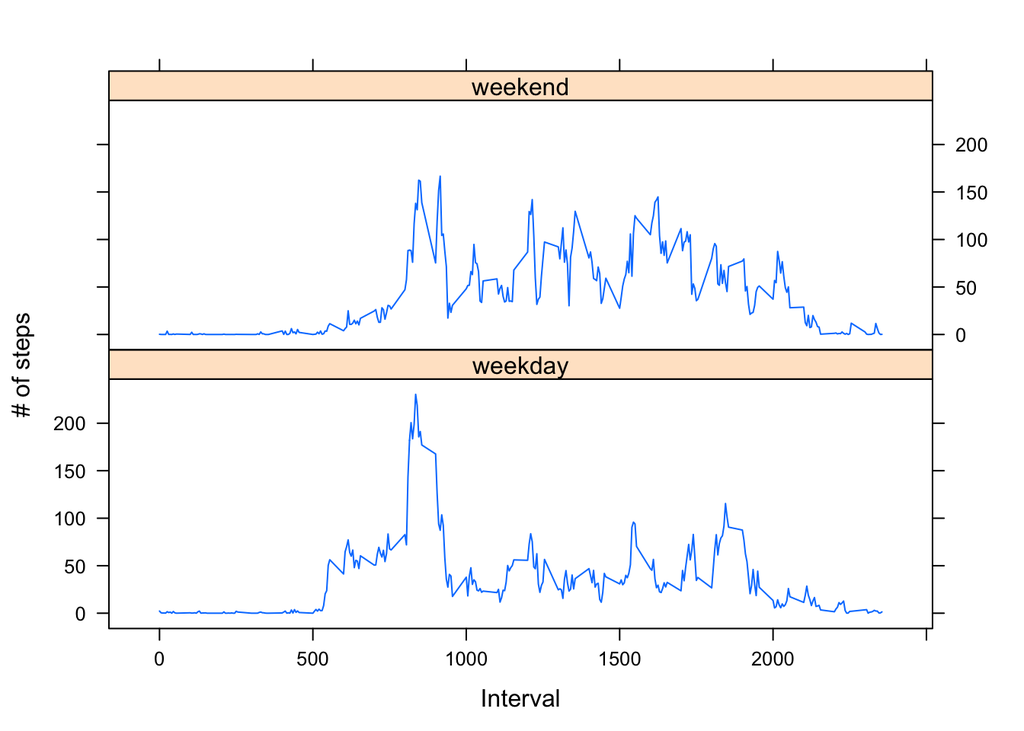

```r
wk_df <- aggregate(steps ~ wk+interval, data=df_impute, FUN=mean)

library(lattice)
xyplot(steps ~ interval | factor(wk),
       layout = c(1, 2),
       xlab="Interval",
       ylab="# of steps",
       type="l",
       lty=1,
       data=wk_df)
```

# Submitting the Assignment

Commit the your completed PA1_template.Rmd file to the master branch of your git repository (you should already be on the master branch unless you created new ones)

Commit your PA1_template.md and PA1_template.html files produced by processing your R markdown file with knit2html() function in R (from the knitr package) by running the function from the console.

If your document has figures included (it should) then they should have been placed in the figure/ directory by default (unless you overrided the default). Add and commit the figure/ directory to yoru git repository so that the figures appear in the markdown file when it displays on github.

Push your master branch to GitHub.